# IS THE UNEMPLOYMENT RATE SIMPLE MOVING AVERAGE A RELIABLE RECESSION INDICATOR FOR THE STOCK MARKET?

Mark Black

10/18/2016

#### Strategy Overview

Famed bond guru Jeff Gundaluch, CEO of Doubleline Capital LP, just saw one of his favorite recession indicators starting to flash red or bearish. I decided to see how reliable the Unemployment Rate indicator is in terms of a trading strategy.

Bloomberg article: http://www.bloomberg.com/news/articles/2016-10-07/one-of-jeff-gundlach-s-favorite-recession-indicators-just-got-triggered

The recession signal is when the Unemployment Rate (UR) crosses over the 12 month moving average (using Simple Moving Average (SMA) ). Today’s the BLS announced the Unemployment Rate ticked up to 5.0 which is .1 above the 12 month moving average at 4.9.

So looking back let’s take a quick simple look at how “actionable” this indicator is in terms of going long or short the market. In this simple strategy below:

#### PORTFOLIO PARAMETERS

Capital: $1,0000,000 USD  
Period: 1/1/2000 – 10/6/2016  
Allocation: All

#### TRADES

[1] “2000-08-02 00:00:00 SPY -6950 @ 144.593704”  
[1] “2000-09-05 00:00:00 SPY 6950 @ 151.281204”  
[1] “2000-09-05 00:00:00 SPY 6557 @ 151.281204”  
[1] “2001-01-02 00:00:00 SPY -6557 @ 128.8125”  
[1] “2001-01-02 00:00:00 SPY -7623 @ 128.8125”  
[1] “2002-10-02 00:00:00 SPY 7623 @ 83.150002”  
[1] “2002-10-02 00:00:00 SPY 11666 @ 83.150002”  
[1] “2002-11-04 00:00:00 SPY -11666 @ 91.129997”  
[1] “2002-11-04 00:00:00 SPY -11078 @ 91.129997”  
[1] “2003-10-02 00:00:00 SPY 11078 @ 102.449997”  
[1] “2003-10-02 00:00:00 SPY 9796 @ 102.449997”  
[1] “2007-06-04 00:00:00 SPY -9796 @ 154.100006”  
[1] “2007-06-04 00:00:00 SPY -6490 @ 154.100006”  
[1] “2010-05-03 00:00:00 SPY 6490 @ 120.349998”  
[1] “2010-05-03 00:00:00 SPY 8417 @ 120.349998”  
[1] “2010-11-02 00:00:00 SPY -8417 @ 119.470001”  
[1] “2010-11-02 00:00:00 SPY -8437 @ 119.470001”  
[1] “2010-12-02 00:00:00 SPY 8437 @ 122.559998”  
[1] “2010-12-02 00:00:00 SPY 8264 @ 122.559998”  
[1] “2016-09-02 00:00:00 SPY -8264 @ 218.369995”  
[1] “2016-09-02 00:00:00 SPY -4600 @ 218.369995”

## Here are the results of the backtest:

### Load the necessary libraries

```r
require(quantstrat)
require(FinancialInstrument)
require(blotter)
require(Quandl)
require(quantmod)
require(PerformanceAnalytics)
```

### Import the Unemployment Rate from the St. Louis Federal Reserve

```r
UNRATE = getSymbols('UNRATE', src='FRED', auto.assign=F)
names(UNRATE) <- "UNRATE"
UNRATE$UNRATE.12SMA <- SMA(UNRATE,12)
UNRATE <- na.omit(UNRATE)
UNRATE$SIGNAL <- ifelse(UNRATE$UNRATE>UNRATE$UNRATE.12SMA,1,0)
```

### Custom Functions

```r
osFixedDollar <- function(timestamp,orderqty, portfolio, symbol, ruletype, ...)
{
  #logwarn("started osFixedDollar")
  ClosePrice <- as.numeric(Cl(mktdata[timestamp,]))
  orderqty <- sign(orderqty)*round(tradeSize/ClosePrice)
  return(orderqty)
}
```

### Setting up the Portfolio

```r
# Modified maCross
ttz <- Sys.getenv('TZ')
Sys.setenv(TZ='UTC')

stock.str <- 'SPY'
currency('USD')
stock(stock.str, currency='USD', multiplier=1)

initDate <- "2000-01-01"
endDate <- Sys.Date()

tradeSize <- 1000000
initEq <- tradeSize

portfolio.st <- 'model'
account.st <- 'model'

suppressWarnings({
  rm(list=paste("order_book",portfolio.st,sep="."),pos=.strategy)
  rm(list=c(paste("account",account.st,sep="."),
            paste("portfolio",portfolio.st,sep=".")),pos=.blotter)
  rm("strat")
})
initPortf(portfolio.st,symbols=stock.str, initDate=initDate)
initAcct(account.st,portfolios=portfolio.st, initDate=initDate,initEq=initEq)
initOrders(portfolio=portfolio.st,initDate=initDate)

strat <- strategy(portfolio.st)
```

### Pulling the Data

```r
# Pull SPY data from Yahoo Finance
getSymbols.google(stock.str, from=initDate, to=endDateenv=.GlobalEnv)
colnames(SPY) = c("Open", "High", "Low", "Adjusted", "Volume")
# Add model indicator to SPY data
SPY <- na.omit(merge(SPY, UNRATE$SIGNAL, fill=na.locf))
```

### Trade Signals and Rules

```r
# signals
# not sure what the model values are, so I assume a long signal
# Short
strat <- add.signal(strat, "sigThreshold",
                    arguments = list(column = "SIGNAL",
                                     threshold = 1,
                                     relationship = "eq",
                                     cross = TRUE),
                    label = "pred.gt.03")
strat <- add.signal(strat, "sigThreshold",
                    arguments = list(column = "SIGNAL",
                                     threshold = 0,
                                     relationship = "eq",
                                     cross = TRUE),
                    label = "pred.lt.04")

# Long
strat <- add.signal(strat, "sigThreshold",
                    arguments = list(column = "SIGNAL",
                                     threshold = 1,
                                     relationship = "eq",
                                     cross = TRUE),
                    label = "pred.gt.02")
strat <- add.signal(strat, "sigThreshold",
                    arguments = list(column = "SIGNAL",
                                     threshold = 0,
                                     relationship = "eq",
                                     cross = TRUE),
                    label = "pred.lt.01")



## RULES
# Short
strat <- add.rule(strat, 'ruleSignal',
                  arguments = list(sigcol = "pred.gt.03",
                                   sigval = TRUE,
                                   orderqty = -1,
                                   ordertype = 'market',
                                   orderside = 'short',
                                   osFUN=osFixedDollar,
                                   prefer="Close",
                                   TxnFees=-30,
                                   replace=FALSE),
                  type = 'enter',
                  label = 'enter.shot')

strat <- add.rule(strat, 'ruleSignal',
                  arguments = list(sigcol = "pred.lt.04",
                                   sigval = TRUE,
                                   orderqty = 'all',
                                   ordertype = 'market',
                                   orderside = 'short',
                                   TxnFees=-30,
                                   replace=TRUE),
                  type = 'exit',
                  label = 'exit.short')

# Long
strat <- add.rule(strat, 'ruleSignal',
                  arguments = list(sigcol = "pred.lt.01",
                                   sigval = TRUE,
                                   orderqty = 1,
                                   ordertype = 'market',
                                   orderside = 'long',
                                   osFUN=osFixedDollar,
                                   prefer="Close",
                                   TxnFees=-30,
                                   replace=FALSE),
                  type = 'enter',
                  label = 'enter.long')

strat <- add.rule(strat, 'ruleSignal',
                  arguments = list(sigcol = "pred.gt.02",
                                   sigval = TRUE,
                                   orderqty = 'all',
                                   ordertype = 'market',
                                   orderside = 'long',
                                   TxnFees=-30,
                                   replace=TRUE),
                  type = 'exit',
                  label = 'exit.long')
```

### Results of the Backtest

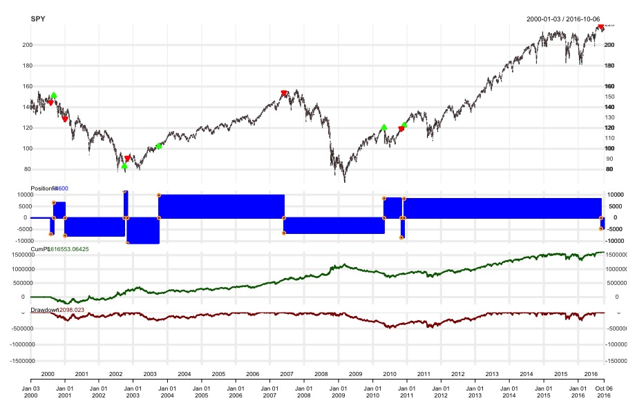

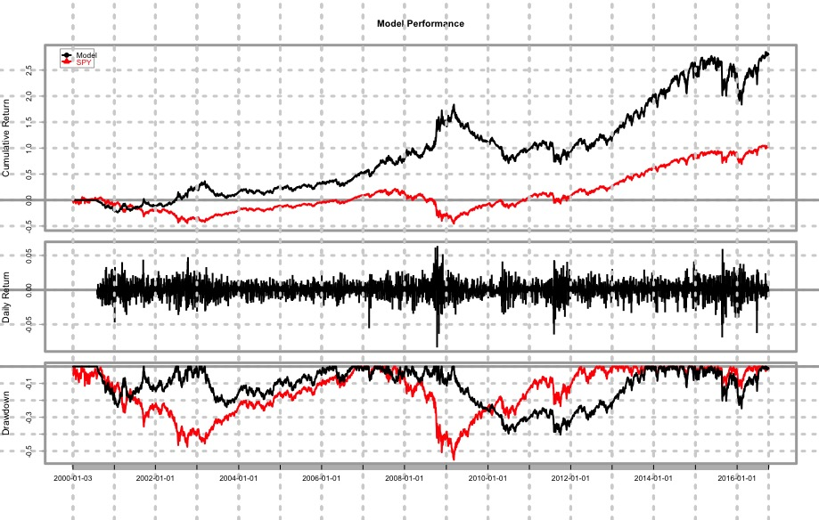

```r
# run backtest
out <- applyStrategy(strategy=strat, portfolios=portfolio.st)
updatePortf(Portfolio='model', Dates=paste('::',as.Date(Sys.time()),sep=''))

par(lwd=3)
chart.Posn(Portfolio='model',Symbol=stock.str)

book    <- getOrderBook('model')
stats   <- tradeStats('model')
ptstats <- perTradeStats('model')
rets    <- PortfReturns('model')
table.AnnualizedReturns(rets)
SharpeRatio.annualized(rets)
maxDrawdown(rets)
txns    <- getTxns('model', stock.str)

# SPY rets v Model rets
SPYrets <- Return.calculate(Ad(SPY))
model.spy.rets <- merge(rets, SPYrets, join='inner')
names(model.spy.rets) <- c("Model","SPY")

charts.PerformanceSummary(model.spy.rets)

#Date workaround, remove later
Sys.setenv(TZ=ttz)
```